# Introduction to Data Analysis in Python

```python
import pandas as pd
```

Firstly, if we read the data in without passing any extra arguments, we get:

```python
temperature = pd.read_csv(
    "https://milliams.com/courses/data_analysis_python/meantemp_monthly_totals.txt",
)
temperature.head()
```

|  | Mean Central England Temperature (Degrees Celsius) |
| --- | --- |
| 1659-1973 Manley (Q.J.R.METEOROL.SOC. | 1974) |
| 1974 on Parker et al. (INT.J.CLIM. | 1992) |
| Parker and Horton (INT.J.CLIM. | 2005) |
| Year Jan Feb Mar Apr May Jun Jul Aug Sep Oct Nov Dec Annual | NaN |
| 1659 3.0 4.0 6.0 7.0 11.0 13.0 16.0 16.0 13.0 10.0 5.0 2.0 8.9 | NaN |

So we need to dot he same as before, setting the `skiprows` argument:

```python
temperature = pd.read_csv(
    "https://milliams.com/courses/data_analysis_python/meantemp_monthly_totals.txt",
    skiprows=4,  # skip first 4 rows of the header
)
temperature.head()
```

|  | Year Jan Feb Mar Apr May Jun Jul Aug Sep Oct Nov Dec Annual |
| --- | --- |
| 0 | 1659 3.0 4.0 6.0 7.0 11.0 13... |
| 1 | 1660 0.0 4.0 6.0 9.0 11.0 14... |
| 2 | 1661 5.0 5.0 6.0 8.0 11.0 14... |
| 3 | 1662 5.0 6.0 6.0 8.0 11.0 15... |
| 4 | 1663 1.0 1.0 5.0 7.0 10.0 14... |

It's not separating the columns correctly so if we look at the data and see spaces, we *might* think that useing `sep=" "` would work, but if we try it:

```python
temperature = pd.read_csv(
    "https://milliams.com/courses/data_analysis_python/meantemp_monthly_totals.txt",
    skiprows=4,
    sep=" ",  # try this...
)
temperature.head()
```

|  | Unnamed: 0 | Unnamed: 1 | Year | Unnamed: 3 | Unnamed: 4 | Unnamed: 5 | Jan | Unnamed: 7 | Unnamed: 8 | Unnamed: 9 | ... | Unnamed: 43 | Unnamed: 44 | Unnamed: 45 | Nov | Unnamed: 47 | Unnamed: 48 | Unnamed: 49 | Dec | Unnamed: 51 | Annual |
| --- | --- | --- | --- | --- | --- | --- | --- | --- | --- | --- | --- | --- | --- | --- | --- | --- | --- | --- | --- | --- | --- |
| 0 | NaN | NaN | 1659 | NaN | NaN | NaN | 3.0 | NaN | NaN | NaN | ... | NaN | 2.0 | NaN | NaN | NaN | 8.9 | NaN | NaN | NaN | NaN |
| 1 | NaN | NaN | 1660 | NaN | NaN | NaN | 0.0 | NaN | NaN | NaN | ... | NaN | 5.0 | NaN | NaN | NaN | 9.1 | NaN | NaN | NaN | NaN |
| 2 | NaN | NaN | 1661 | NaN | NaN | NaN | 5.0 | NaN | NaN | NaN | ... | NaN | 6.0 | NaN | NaN | NaN | 9.8 | NaN | NaN | NaN | NaN |
| 3 | NaN | NaN | 1662 | NaN | NaN | NaN | 5.0 | NaN | NaN | NaN | ... | NaN | 3.0 | NaN | NaN | NaN | 9.5 | NaN | NaN | NaN | NaN |
| 4 | NaN | NaN | 1663 | NaN | NaN | NaN | 1.0 | NaN | NaN | NaN | ... | NaN | 5.0 | NaN | NaN | NaN | 8.6 | NaN | NaN | NaN | NaN |

5 rows × 53 columns

That doesn't look right. This is because `sep=" "` means "use a single space" as the separator, but in the data most columns are separated by multiple spaces. To make it use "any number of spaces" as the separator, you can instead set `delim_whitespace=True`:

```python
temperature = pd.read_csv(
    "https://milliams.com/courses/data_analysis_python/meantemp_monthly_totals.txt",
    skiprows=4,
    delim_whitespace=True,  # whitespace-separated columns
)
temperature.head()
```

|  | Year | Jan | Feb | Mar | Apr | May | Jun | Jul | Aug | Sep | Oct | Nov | Dec | Annual |
| --- | --- | --- | --- | --- | --- | --- | --- | --- | --- | --- | --- | --- | --- | --- |
| 0 | 1659 | 3.0 | 4.0 | 6.0 | 7.0 | 11.0 | 13.0 | 16.0 | 16.0 | 13.0 | 10.0 | 5.0 | 2.0 | 8.9 |
| 1 | 1660 | 0.0 | 4.0 | 6.0 | 9.0 | 11.0 | 14.0 | 15.0 | 16.0 | 13.0 | 10.0 | 6.0 | 5.0 | 9.1 |
| 2 | 1661 | 5.0 | 5.0 | 6.0 | 8.0 | 11.0 | 14.0 | 15.0 | 15.0 | 13.0 | 11.0 | 8.0 | 6.0 | 9.8 |
| 3 | 1662 | 5.0 | 6.0 | 6.0 | 8.0 | 11.0 | 15.0 | 15.0 | 15.0 | 13.0 | 11.0 | 6.0 | 3.0 | 9.5 |
| 4 | 1663 | 1.0 | 1.0 | 5.0 | 7.0 | 10.0 | 14.0 | 15.0 | 15.0 | 13.0 | 10.0 | 7.0 | 5.0 | 8.6 |

That looks much better! Now we set the `index_col`:

```python
temperature = pd.read_csv(
    "https://milliams.com/courses/data_analysis_python/meantemp_monthly_totals.txt",
    skiprows=4,
    delim_whitespace=True,
    index_col="Year",  # Set the index
)
temperature.head()
```

| Year | Jan | Feb | Mar | Apr | May | Jun | Jul | Aug | Sep | Oct | Nov | Dec | Annual |
| --- | --- | --- | --- | --- | --- | --- | --- | --- | --- | --- | --- | --- | --- |
| 1659 | 3.0 | 4.0 | 6.0 | 7.0 | 11.0 | 13.0 | 16.0 | 16.0 | 13.0 | 10.0 | 5.0 | 2.0 | 8.9 |
| 1660 | 0.0 | 4.0 | 6.0 | 9.0 | 11.0 | 14.0 | 15.0 | 16.0 | 13.0 | 10.0 | 6.0 | 5.0 | 9.1 |
| 1661 | 5.0 | 5.0 | 6.0 | 8.0 | 11.0 | 14.0 | 15.0 | 15.0 | 13.0 | 11.0 | 8.0 | 6.0 | 9.8 |
| 1662 | 5.0 | 6.0 | 6.0 | 8.0 | 11.0 | 15.0 | 15.0 | 15.0 | 13.0 | 11.0 | 6.0 | 3.0 | 9.5 |
| 1663 | 1.0 | 1.0 | 5.0 | 7.0 | 10.0 | 14.0 | 15.0 | 15.0 | 13.0 | 10.0 | 7.0 | 5.0 | 8.6 |

And, as we should always do, we plot the data we've just read in:

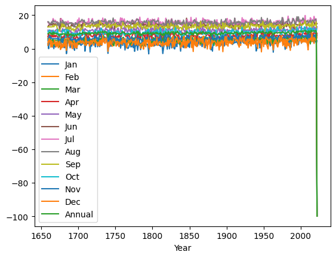

```python
temperature.plot()
```

Something is wrong with this. There's a line on the right-hand side which seems wrong. If we look at the last few lines of the data to see what's going on:

```python
temperature.tail()
```

| Year | Jan | Feb | Mar | Apr | May | Jun | Jul | Aug | Sep | Oct | Nov | Dec | Annual |
| --- | --- | --- | --- | --- | --- | --- | --- | --- | --- | --- | --- | --- | --- |
| 2018 | 5.3 | 3.1 | 5.0 | 9.9 | 13.3 | 16.1 | 19.3 | 16.8 | 13.7 | 10.5 | 8.3 | 6.8 | 10.7 |
| 2019 | 4.0 | 6.9 | 7.9 | 9.1 | 11.2 | 14.2 | 17.6 | 17.2 | 14.3 | 9.8 | 6.2 | 5.7 | 10.4 |
| 2020 | 6.4 | 6.4 | 6.8 | 10.5 | 12.6 | 15.3 | 15.8 | 17.7 | 14.0 | 10.4 | 8.5 | 4.9 | 10.8 |
| 2021 | 3.2 | 5.3 | 7.3 | 6.5 | 10.3 | 15.5 | 17.8 | 16.0 | 16.0 | 12.0 | 7.2 | 6.3 | 10.3 |
| 2022 | 4.7 | 6.9 | 8.0 | 9.2 | 13.1 | 14.9 | -99.9 | -99.9 | -99.9 | -99.9 | -99.9 | -99.9 | -99.9 |

We can see there are some `-99.9` in the data, repsenting missing data. We should fix this with `na_values`:

```python
temperature = pd.read_csv(
    "https://milliams.com/courses/data_analysis_python/meantemp_monthly_totals.txt",
    skiprows=4,
    delim_whitespace=True,
    index_col="Year",
    na_values=["-99.9"]
)
temperature.tail()
```

| Year | Jan | Feb | Mar | Apr | May | Jun | Jul | Aug | Sep | Oct | Nov | Dec | Annual |
| --- | --- | --- | --- | --- | --- | --- | --- | --- | --- | --- | --- | --- | --- |
| 2018 | 5.3 | 3.1 | 5.0 | 9.9 | 13.3 | 16.1 | 19.3 | 16.8 | 13.7 | 10.5 | 8.3 | 6.8 | 10.7 |
| 2019 | 4.0 | 6.9 | 7.9 | 9.1 | 11.2 | 14.2 | 17.6 | 17.2 | 14.3 | 9.8 | 6.2 | 5.7 | 10.4 |
| 2020 | 6.4 | 6.4 | 6.8 | 10.5 | 12.6 | 15.3 | 15.8 | 17.7 | 14.0 | 10.4 | 8.5 | 4.9 | 10.8 |
| 2021 | 3.2 | 5.3 | 7.3 | 6.5 | 10.3 | 15.5 | 17.8 | 16.0 | 16.0 | 12.0 | 7.2 | 6.3 | 10.3 |
| 2022 | 4.7 | 6.9 | 8.0 | 9.2 | 13.1 | 14.9 | NaN | NaN | NaN | NaN | NaN | NaN | NaN |

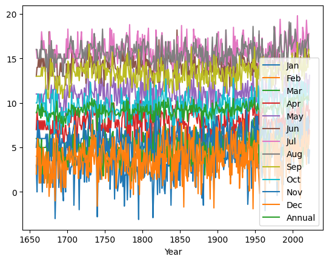

```python
temperature.plot()
```